# R Notebook

# Hausaufgabe 2

## Dateien importieren und bereinigen

```r
library(readr)
book_ratings <- read_delim("BX-CSV-Dump/BX-Book-Ratings.csv",
    ";", escape_double = FALSE, trim_ws = TRUE)
library(readr)
books <- read_delim("BX-CSV-Dump/BX-Books.csv",
    ";", escape_backslash = TRUE, escape_double = FALSE,
    trim_ws = TRUE)
library(readr)
users <- read_delim("BX-CSV-Dump/BX-Users.csv",
    ";", escape_double = FALSE, trim_ws = TRUE)
library(tidyverse)
```

Zunächst wird dafür gesorgt, dass alles klein geschrieben wird und beliebte Sonderzeichen durch lesbare Alternativen ersetzt werden, um Doppelnennungen des gleichen Autors, Titels etc. möglichst zu vermeiden. Es ist nicht möglich, alles anzupassen, aber eben so viel wie möglich.

```r
books <- books %>%
  select(-`Image-URL-S`, -`Image-URL-M`, -`Image-URL-L`) %>%
  mutate(`Book-Author` = str_to_lower(`Book-Author`)) %>%
  mutate(`Publisher` = str_to_lower(Publisher)) %>%
  mutate(`Book-Title` = str_to_lower(`Book-Title`)) %>%
  mutate(`Book-Author` = str_replace(`Book-Author`, "ç", "c")) %>%
  mutate(`Book-Author` = str_replace(`Book-Author`, "ñ", "n")) %>%
  mutate(`Book-Author` = str_replace(`Book-Author`, "é", "e")) %>%
  mutate(`Book-Author` = str_replace(`Book-Author`, "è", "e")) %>%
  mutate(`Book-Author` = str_replace(`Book-Author`, "á", "a")) %>%
  mutate(`Book-Author` = str_replace(`Book-Author`, "à", "a")) %>%
  mutate(`Book-Author` = str_replace(`Book-Author`, "í", "i")) %>%
  mutate(`Book-Title` = str_replace(`Book-Title`, "ç", "c")) %>%
  mutate(`Book-Title` = str_replace(`Book-Title`, "ñ", "n")) %>%
  mutate(`Book-Title` = str_replace(`Book-Title`, "é", "e")) %>%
  mutate(`Book-Title` = str_replace(`Book-Title`, "è", "e")) %>%
  mutate(`Book-Title` = str_replace(`Book-Title`, "á", "a")) %>%
  mutate(`Book-Title` = str_replace(`Book-Title`, "à", "a")) %>%
  mutate(`Book-Title` = str_replace(`Book-Title`, "í", "i")) %>%
  mutate(`Publisher` = str_replace(`Publisher`, "ç", "c")) %>%
  mutate(`Publisher` = str_replace(`Publisher`, "ñ", "n")) %>%
  mutate(`Publisher` = str_replace(`Publisher`, "é", "e")) %>%
  mutate(`Publisher` = str_replace(`Publisher`, "è", "e")) %>%
  mutate(`Publisher` = str_replace(`Publisher`, "á", "a")) %>%
  mutate(`Publisher` = str_replace(`Publisher`, "à", "a")) %>%
  mutate(`Publisher` = str_replace(`Publisher`, "í", "i"))
```

Bei den Ortsangaben sollen aus dem gleichen Grund nur noch die Länder angezeigt werden. Das Alter soll von R als Nummer gelesen werden, damit statt NULL NA in leeren Feldern steht.

```r
users <- users %>%
  mutate(Location = str_remove(Location, ".*,")) %>%
  mutate(Age = as.numeric(Age))
```

Alle Bewertungen, die eine 0 enthalten, sollen nun NA enthalten. Es handelt sich schließlich nicht um besonders schlechte Bewertungen, sondern um leere Felder.

```r
book_ratings$`Book-Rating`[book_ratings$`Book-Rating` == 0] <- NA
books$`Year-Of-Publication`[books$`Year-Of-Publication` == 0] <- NA
```

Anschließend werden die bereinigten Datensätze zu einem neuen Datensatz namens joined vereint.

```r
joined <- books %>%
  left_join(book_ratings) %>%
  left_join(users)
joined %>%
  group_by(Publisher) %>%
  mutate(anzahl_bewertungen = n()) %>%
  select(Publisher, `Book-Title`, anzahl_bewertungen) %>%
  unique()
```

| Publisher | Book-Title | anzahl_bewertungen |
| --- | --- | --- |
| oxford university press | classical mythology | 2759 |
| harperflamingo canada | clara callan | 47 |
| harperperennial | decision in normandy | 46 |
| farrar straus giroux | flu: the story of the great influenza pandemic of 1918 and the search for the virus that caused it | 897 |
| w. w. norton &amp; company | the mummies of urumchi | 2035 |
| putnam pub group | the kitchen god's wife | 3926 |
| berkley publishing group | what if?: the world's foremost military historians imagine what might have been | 28621 |
| audioworks | pleading guilty | 360 |
| random house | under the black flag: the romance and the reality of life among the pirates | 3576 |
| scribner | where you'll find me: and other stories | 7410 |

[output cut: 9990 more lines]

## Gibt es eine Korrelation zwischen Anzahl Bücher pro Publisher und Anzahl Ratings, die die Bücher eines Publishers erhalten?

Zunächst werden die Bücher nach Verlag gruppiert. Dann wird eine neue Variable erstellt, die die Anzahl der Bewertungen jedes Verlags zusammenfasst. Mit select werden die Spalten ausgewählt, die für die Berechnung der nächsten Variable relevant sind (Verlag und Buchtitel), sowie die neue Variable. Mit unique werden Mehrfachnennungen zusammengefasst. Anschließend wird eine weitere neue Variable erstellt, die die Anzahl der Bücher pro Verlag anzeigt. Es soll nun geprüft werden, ob zwischen den beiden Variablen eine Korrelation besteht. Dafür brauchen wir nur die beiden neu erzeugten Variablen und sortieren die anderen mit select aus. Die Variablen werden in einem Datensatz namens aufgabe1 gespeichert.

```r
aufgabe1 <- joined %>%
  group_by(Publisher) %>%
  mutate(anzahl_bewertungen = n()) %>%
  select(Publisher, `Book-Title`, anzahl_bewertungen) %>%
  unique() %>%
  mutate(anzahl_buecher = n()) %>%
  ungroup() %>%
  select(anzahl_buecher, anzahl_bewertungen)
```

Nun kann mit cor.test die Korrelation zwischen den beiden Variablen durch den Korrelationskoeffizienten berechnet werden.

```r
cor.test(aufgabe1$anzahl_buecher, aufgabe1$anzahl_bewertungen)
```

```
##
##  Pearson's product-moment correlation
##
## data:  aufgabe1$anzahl_buecher and aufgabe1$anzahl_bewertungen
## t = 759.6, df = 264862, p-value < 2.2e-16
## alternative hypothesis: true correlation is not equal to 0
## 95 percent confidence interval:
##  0.8266759 0.8290723
## sample estimates:
##       cor
## 0.8278778
```

Der Korrelationskoeffizient beträgt ca. 0,83, das heißt die Korrelation zwischen der Anzahl der Bücher pro Verlag und der Anzahl der Bewertungen der Bücher eines Verlags ist sehr stark.

## Haben ältere Bücher mehr Ratings, weil sie mehr Zeit haben, um Ratings zu sammeln?

Bei den Veröffentlichungsjahren werden alle herausgefiltert, die noch nicht erschienen sein können (größer als 2021) oder wo eine sinnvolle Angabe fehlt (0). Es gibt nur 4 Bücher, die vor 1900 erschienen sind; diese sortiere ich der Übersicht halber ebenfalls aus. Es werden auch alle Einträge herausgefiltert, in denen keine Bewertung steht. Wenn wir die Bücher nach Erscheinungsjahr gruppieren, können wir uns mit mutate eine neue Variable erstellen lassen, die die Anzahl der Bewertungen pro Erscheinungsjahr anzeigt.

```r
aufgabe2_0 <-joined %>%
  filter(`Year-Of-Publication` >= 1900, `Year-Of-Publication` <= 2021) %>%
  filter(`Book-Rating` > 0) %>%
  group_by(`Year-Of-Publication`) %>%
  mutate(anzahl_bewertungen = n()) %>%
  mutate(alter_buecher = 2021 - `Year-Of-Publication`)
```

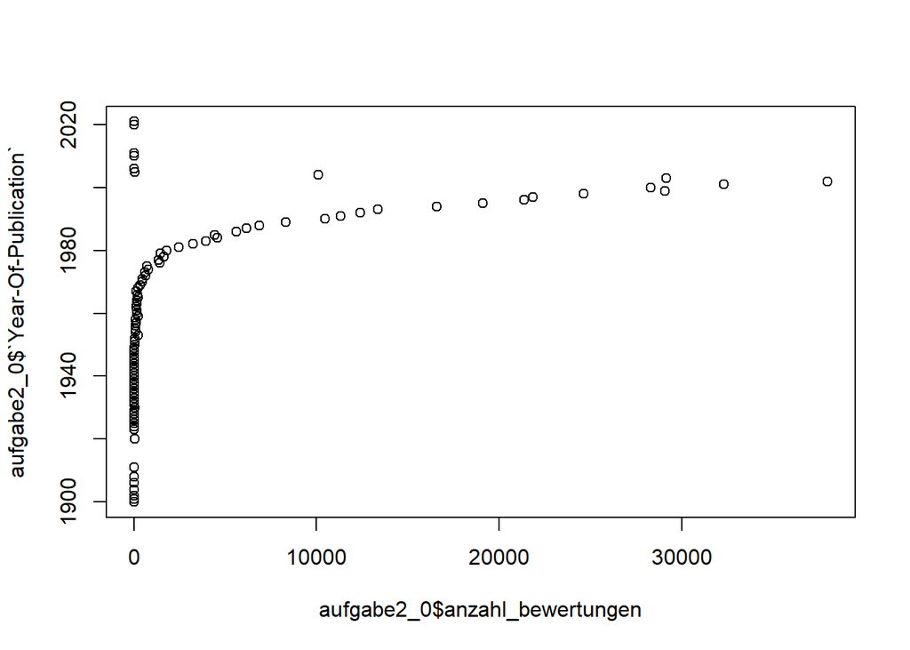

```r
plot(aufgabe2_0$anzahl_bewertungen, aufgabe2_0$`Year-Of-Publication`)
```

```r
aufgabe2_1 <-joined %>%
  filter(`Year-Of-Publication` >= 1990, `Year-Of-Publication` <= 2021) %>%
  filter(`Book-Rating` > 0) %>%
  group_by(`Year-Of-Publication`) %>%
  mutate(anzahl_bewertungen = n())
```

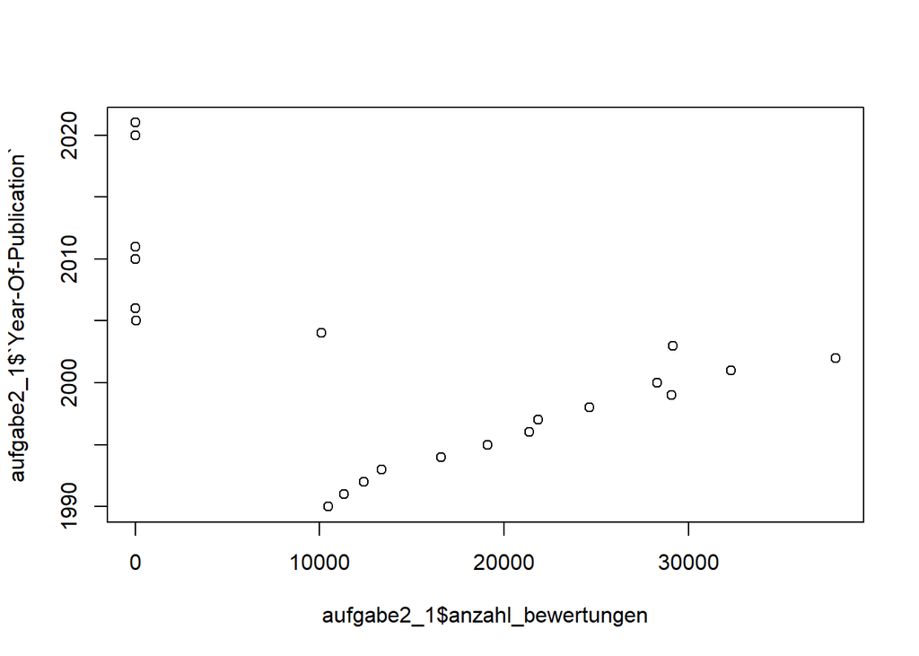

```r
plot(aufgabe2_1$anzahl_bewertungen, aufgabe2_1$`Year-Of-Publication`)
```

```r
aufgabe2_2 <-joined %>%
  filter(`Year-Of-Publication` >= 2000, `Year-Of-Publication` <= 2021) %>%
  filter(`Book-Rating` > 0) %>%
  group_by(`Year-Of-Publication`) %>%
  mutate(anzahl_bewertungen = n()) %>%
  mutate(alter_buecher = 2021 - `Year-Of-Publication`)
```

```r
cor.test(aufgabe2_2$alter_buecher, aufgabe2_2$anzahl_bewertungen)
```

```
##
##  Pearson's product-moment correlation
##
## data:  aufgabe2_2$alter_buecher and aufgabe2_2$anzahl_bewertungen
## t = 129.05, df = 137960, p-value < 2.2e-16
## alternative hypothesis: true correlation is not equal to 0
## 95 percent confidence interval:
##  0.3234704 0.3328873
## sample estimates:
##      cor
## 0.328187
```

Davor ist sogar eine negative Korrelation erkennbar (p = -0,8317131), was bedeutet, dass eher das Gegenteil der Fragestellung der Fall ist: Je neuer die Bücher insgesamt sind, desto mehr Bewertungen haben sie in diesem Datensatz bekommen. Diese Tendenz ändert sich aber ab den 2000ern, wie oben gezeigt wurde, und es lässt sich vermuten, dass sie sich umkehren wird.

```r
cor.test(aufgabe2_0$alter_buecher, aufgabe2_0$anzahl_bewertungen)
```

```
##
##  Pearson's product-moment correlation
##
## data:  aufgabe2_0$alter_buecher and aufgabe2_0$anzahl_bewertungen
## t = -921.07, df = 378044, p-value < 2.2e-16
## alternative hypothesis: true correlation is not equal to 0
## 95 percent confidence interval:
##  -0.8326931 -0.8307279
## sample estimates:
##        cor
## -0.8317131
```

## Kann man mit einer linearen Regression etwas davon vorhersagen?

### zu Aufgabe 1:

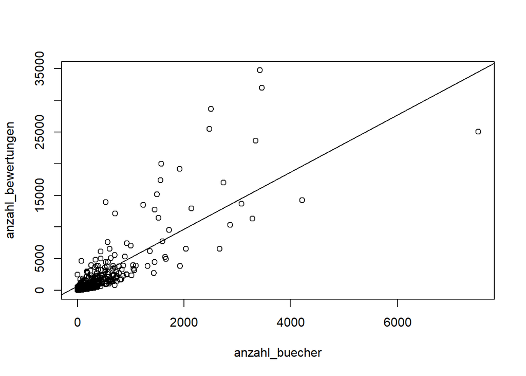

```r
aufgabe3_1 <- lm(aufgabe1$anzahl_bewertungen ~ aufgabe1$anzahl_buecher)
plot(aufgabe1)
abline(aufgabe3_1)
```

```r
summary(aufgabe3_1)
```

```
##
## Call:
## lm(formula = aufgabe1$anzahl_bewertungen ~ aufgabe1$anzahl_buecher)
##
## Residuals:
##     Min      1Q  Median      3Q     Max
## -9483.0 -1403.4  -788.3  -622.0 18665.3
##
## Coefficients:
##                          Estimate Std. Error t value Pr(>|t|)
## (Intercept)             6.654e+02  1.085e+01   61.32   <2e-16 ***
## aufgabe1$anzahl_buecher 4.507e+00  5.934e-03  759.60   <2e-16 ***
## ---
## Signif. codes:  0 '***' 0.001 '**' 0.01 '*' 0.05 '.' 0.1 ' ' 1
##
## Residual standard error: 4685 on 264862 degrees of freedom
## Multiple R-squared:  0.6854, Adjusted R-squared:  0.6854
## F-statistic: 5.77e+05 on 1 and 264862 DF,  p-value: < 2.2e-16
```

Der Median liegt näher am 3. Quartil als am 1. Quartil, was heißt, dass die Verteilung der Residuen nicht gleichmäßig um die Gerade verteilt sind. R-quared liegt bei 0,6854, was heißt, dass sich die Anzahl der Bewertungen zu ca. 69% mit der Anzahl der Bücher erklären lässt. Eine lineare Regression kann also nur bis zu einem gewissen Grad bei der Vorhersage weiterer Werte weiterhelfen.

### zu Aufgabe 2:

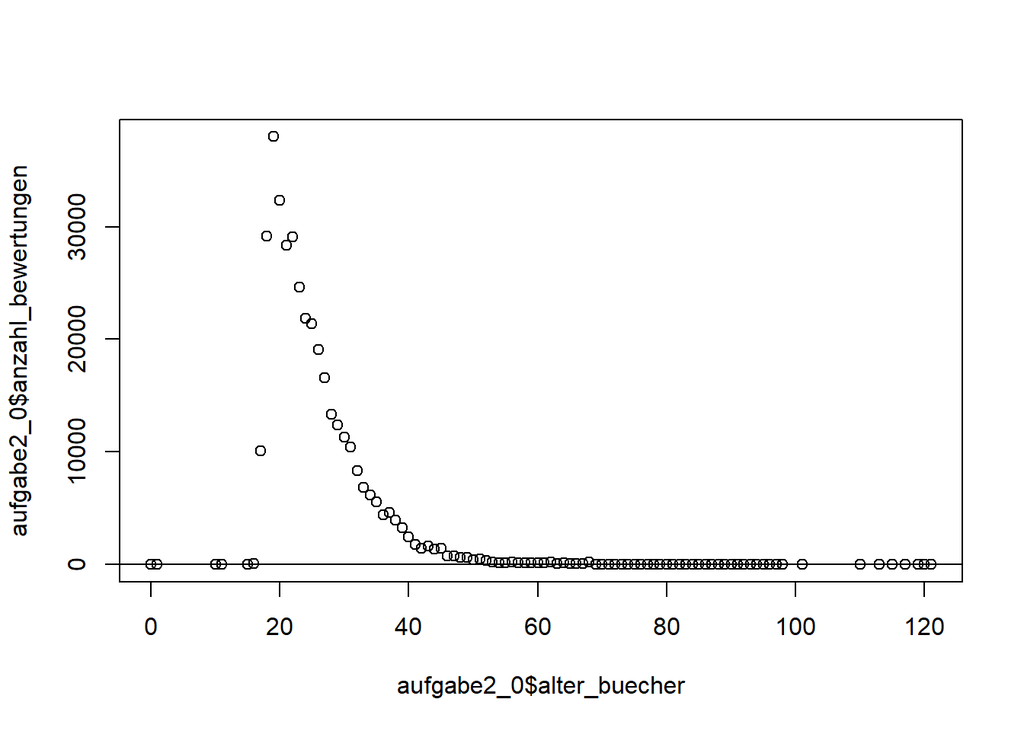

```r
aufgabe3_2 <- lm(aufgabe2_0$alter_buecher ~ aufgabe2_0$anzahl_bewertungen)
plot(aufgabe2_0$alter_buecher, aufgabe2_0$anzahl_bewertungen)
abline(aufgabe3_2)
```

```r
summary(aufgabe3_2)
```

```
##
## Call:
## lm(formula = aufgabe2_0$alter_buecher ~ aufgabe2_0$anzahl_bewertungen)
##
## Residuals:
##     Min      1Q  Median      3Q     Max
## -37.516  -1.065  -0.387   1.058  83.484
##
## Coefficients:
##                                 Estimate Std. Error t value Pr(>|t|)
## (Intercept)                    3.752e+01  1.481e-02  2532.5   <2e-16 ***
## aufgabe2_0$anzahl_bewertungen -5.696e-04  6.184e-07  -921.1   <2e-16 ***
## ---
## Signif. codes:  0 '***' 0.001 '**' 0.01 '*' 0.05 '.' 0.1 ' ' 1
##
## Residual standard error: 4.049 on 378044 degrees of freedom
## Multiple R-squared:  0.6917, Adjusted R-squared:  0.6917
## F-statistic: 8.484e+05 on 1 and 378044 DF,  p-value: < 2.2e-16
```

Hier befindet sich der Median etwas näher am 1. Quartil als am 3. Quartil, die Residuen sind also wieder ungleichmäßg um die Gerade verteilt. R-squared liegt ebenfalls bei 0.6917, also lässt sich die Anzahl der Bewertungen zu 69% mit dem Alter der Bücher erklären. Das lässt sich durch die negative Korrelation erklären. Oben wurde jedoch gezeigt, dass die Tendenz sich ab den 2000ern ändert.

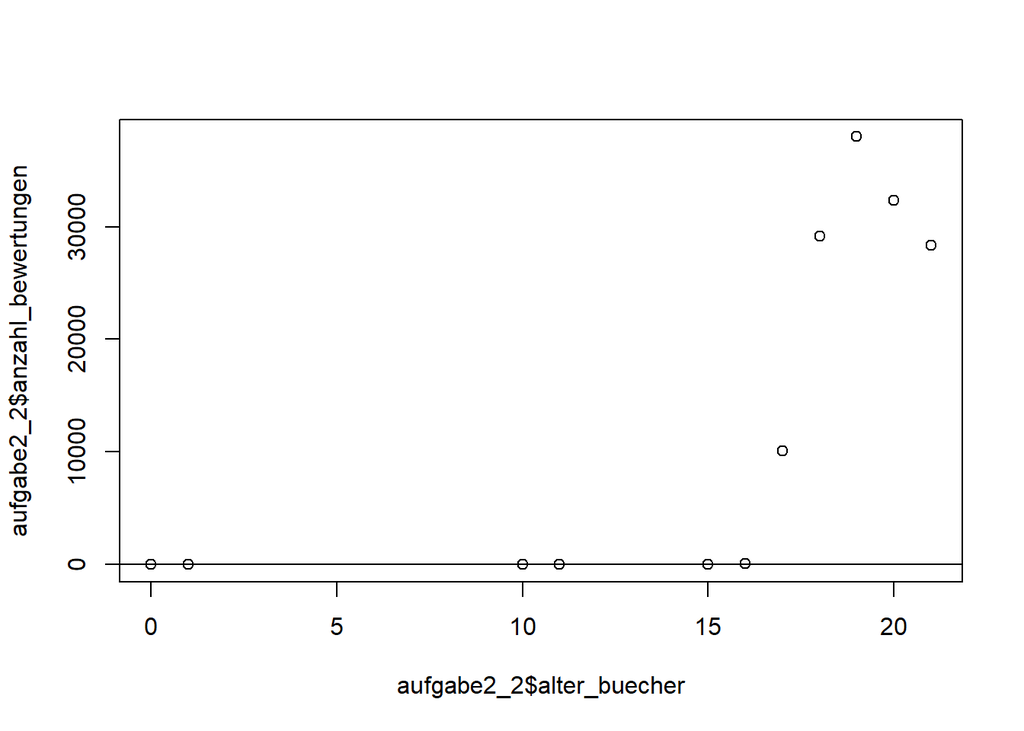

```r
aufgabe3_2 <- lm(aufgabe2_2$alter_buecher ~ aufgabe2_2$anzahl_bewertungen)
plot(aufgabe2_2$alter_buecher, aufgabe2_2$anzahl_bewertungen)
abline(aufgabe3_2)
```

```r
summary(aufgabe3_2)
```

```
##
## Call:
## lm(formula = aufgabe2_2$alter_buecher ~ aufgabe2_2$anzahl_bewertungen)
##
## Residuals:
##      Min       1Q   Median       3Q      Max
## -17.5106  -1.0931  -0.7024   0.6239   1.8553
##
## Coefficients:
##                                Estimate Std. Error t value Pr(>|t|)
## (Intercept)                   1.751e+01  1.410e-02    1242   <2e-16 ***
## aufgabe2_2$anzahl_bewertungen 5.770e-05  4.472e-07     129   <2e-16 ***
## ---
## Signif. codes:  0 '***' 0.001 '**' 0.01 '*' 0.05 '.' 0.1 ' ' 1
##
## Residual standard error: 1.155 on 137960 degrees of freedom
## Multiple R-squared:  0.1077, Adjusted R-squared:  0.1077
## F-statistic: 1.665e+04 on 1 and 137960 DF,  p-value: < 2.2e-16
```

Mit sehr ungleichmäßig verteilten Residuen und einem R-squared von 0,1077 lassen sich mit linearer Regression weitere Werte also nicht vorhersagen.